# Assignment 3

```r
 # abline(lm(Inv_Sep ~ listP_Sep))
```

This is a correlation test between the dependent variable (For Sale Inventory) and an independent variable (Median List Price in September 2021). The correlation is 0.25. This means that there is a small, positve correlation between median list price and the size of the for sale inventory.

```
##
##  Pearson's product-moment correlation
##
## data:  Inv_Sep and listP_Sep
## t = 2.2049, df = 71, p-value = 0.03071
## alternative hypothesis: true correlation is not equal to 0
## 95 percent confidence interval:
##  0.02450486 0.45661860
## sample estimates:
##      cor
## 0.253145
```

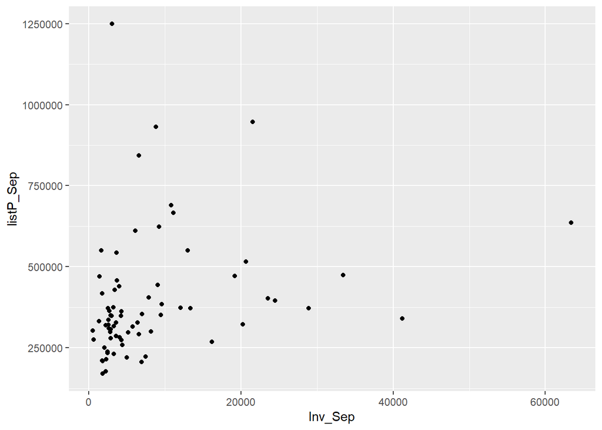

This is a regression test between the dependent variable (For Sale Inventory) and an independent variable (Median Sale Price in September 2021). The p-value is 0.031. There is a small, positive correlation between median sale price and size of the for sale inventory.

```
##
## Call:
## lm(formula = Inv_Sep ~ SaleP_Sep, data = data)
##
## Residuals:
##    Min     1Q Median     3Q    Max
## -17167  -4846  -3412   1161  51719
##
## Coefficients:
##              Estimate Std. Error t value Pr(>|t|)
## (Intercept) 2.876e+03  2.744e+03   1.048   0.2980
## SaleP_Sep   1.386e-02  6.288e-03   2.205   0.0307 *
## ---
## Signif. codes:  0 '***' 0.001 '**' 0.01 '*' 0.05 '.' 0.1 ' ' 1
##
## Residual standard error: 10090 on 71 degrees of freedom
##   (2 observations deleted due to missingness)
## Multiple R-squared:  0.06408,    Adjusted R-squared:  0.0509
## F-statistic: 4.861 on 1 and 71 DF,  p-value: 0.03071
```

This is a t-test between dependent variable (For Sale Inventory) and independent variable (Mortgage Burden). The mortgage burden quality variable is considered high if the 30 percent or higher of an MSA’s homeowner population is considered mortgage burdened. The results of the t-test show that the p-value is less than 0.05, (it is 0.00928). Therefore, there is a difference of homes for sale in MSAs with a high mortgage burden compared to MSAs with a low mortgage burden.

```
##
##  Welch Two Sample t-test
##
## data:  Inv_Sep by MortBurd_Quality
## t = 2.6747, df = 70.904, p-value = 0.00928
## alternative hypothesis: true difference in means between group HighlyBurdened and group LessBurdened is not equal to 0
## 95 percent confidence interval:
##  1366.680 9373.395
## sample estimates:
## mean in group HighlyBurdened   mean in group LessBurdened
##                    10102.204                     4732.167
```

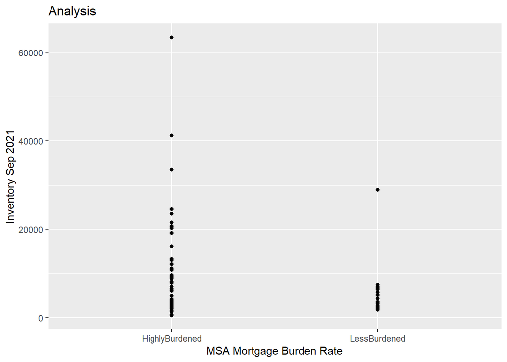

This is a t-test between dependent variable (For Sale Inventory) and independent variable (Median Household Income Quality). The median household income is considered high if the MSA’s median income is above $55,000 annually, and it’s considered low if it is below that. The p-value is not significant, as it is above 0.05, the p-value equals 0.104.

```
##
## Call:
## lm(formula = Inv_Sep ~ MedIncome_Quality, data = data)
##
## Residuals:
##    Min     1Q Median     3Q    Max
##  -7618  -6074  -2870    638  54434
##
## Coefficients:
##                      Estimate Std. Error t value Pr(>|t|)
## (Intercept)              8979       1260   7.128 6.83e-10 ***
## MedIncome_QualityLow    -6702       4068  -1.648    0.104
## ---
## Signif. codes:  0 '***' 0.001 '**' 0.01 '*' 0.05 '.' 0.1 ' ' 1
##
## Residual standard error: 10230 on 71 degrees of freedom
##   (2 observations deleted due to missingness)
## Multiple R-squared:  0.03683,    Adjusted R-squared:  0.02326
## F-statistic: 2.715 on 1 and 71 DF,  p-value: 0.1038
```